# Supermarket Sales Analysis

Vaghasiya Meet R.

# Introduction

This project analyzes supermarket sales data using R.

The main purpose of this project is to understand sales, product performance, customer information, and payment methods.

# Objectives

- To import supermarket sales data.
- To clean and preprocess the data.
- To perform statistical analysis.
- To create graphs and plots.
- To interpret the results.
- To identify important findings from the data.

# Data Importing

First, we import the supermarket sales dataset into R.

```r
data <- read.csv("supermarket_sales.csv.csv")

head(data)
```

```
##   Invoice_ID       Date Branch      City Product_Line Unit_Price Quantity  Tax
## 1       1001 2026-01-02      A  Vadodara         Food         50        3  7.5
## 2       1002 2026-01-03      B Ahmedabad    Beverages         80        5 20.0
## 3       1003 2026-01-05      C     Surat  Electronics        120        2 24.0
## 4       1004 2026-01-07      A  Vadodara         Food         65        4 13.0
## 5       1005 2026-01-09      B Ahmedabad    Household         90        6 27.0
## 6       1006 2026-01-12      C     Surat    Beverages         45        8 18.0
##   Total_Sales Payment Customer_Type Gender
## 1       157.5    Cash        Member   Male
## 2       420.0    Card        Normal Female
## 3       264.0     UPI        Member Female
## 4       273.0     UPI        Normal   Male
## 5       567.0    Cash        Member Female
## 6       378.0    Card        Normal   Male
```

# Data Cleaning and Preprocessing

First, we check the structure of the dataset.

```r
str(data)
```

```
## 'data.frame':    20 obs. of  12 variables:
##  $ Invoice_ID   : int  1001 1002 1003 1004 1005 1006 1007 1008 1009 1010 ...
##  $ Date         : chr  "2026-01-02" "2026-01-03" "2026-01-05" "2026-01-07" ...
##  $ Branch       : chr  "A" "B" "C" "A" ...
##  $ City         : chr  "Vadodara" "Ahmedabad" "Surat" "Vadodara" ...
##  $ Product_Line : chr  "Food" "Beverages" "Electronics" "Food" ...
##  $ Unit_Price   : int  50 80 120 65 90 45 150 55 110 70 ...
##  $ Quantity     : int  3 5 2 4 6 8 1 5 3 7 ...
##  $ Tax          : num  7.5 20 24 13 27 ...
##  $ Total_Sales  : num  158 420 264 273 567 ...
##  $ Payment      : chr  "Cash" "Card" "UPI" "UPI" ...
##  $ Customer_Type: chr  "Member" "Normal" "Member" "Normal" ...
##  $ Gender       : chr  "Male" "Female" "Female" "Male" ...
```

Now, we check for missing values.

```r
colSums(is.na(data))
```

```
##    Invoice_ID          Date        Branch          City  Product_Line
##             0             0             0             0             0
##    Unit_Price      Quantity           Tax   Total_Sales       Payment
##             0             0             0             0             0
## Customer_Type        Gender
##             0             0
```

Now, we check for duplicate records.

```r
sum(duplicated(data))
```

```
## [1] 0
```

Finally, we display the summary of the dataset.

```r
summary(data)
```

```
##    Invoice_ID          Date          Branch          City       Product_Line
##  Min.   :1001   Length   :20   Length   :20   Length   :20   Length   :20
##  1st Qu.:1006   N.unique :20   N.unique : 3   N.unique : 3   N.unique : 4
##  Median :1010   N.blank  : 0   N.blank  : 0   N.blank  : 0   N.blank  : 0
##  Mean   :1010   Min.nchar:10   Min.nchar: 1   Min.nchar: 5   Min.nchar: 4
##  3rd Qu.:1015   Max.nchar:10   Max.nchar: 1   Max.nchar: 9   Max.nchar:11
##  Max.   :1020
##    Unit_Price        Quantity         Tax         Total_Sales         Payment
##  Min.   : 45.00   Min.   :1.00   Min.   : 7.50   Min.   :157.5   Length   :20
##  1st Qu.: 63.75   1st Qu.:3.00   1st Qu.:15.94   1st Qu.:282.8   N.unique : 3
##  Median : 82.50   Median :4.50   Median :20.50   Median :378.8   N.blank  : 0
##  Mean   : 89.75   Mean   :4.55   Mean   :20.25   Mean   :378.4   Min.nchar: 3
##  3rd Qu.:112.50   3rd Qu.:6.00   3rd Qu.:24.12   3rd Qu.:472.5   Max.nchar: 4
##  Max.   :160.00   Max.   :9.00   Max.   :32.00   Max.   :624.8
##    Customer_Type       Gender
##  Length   :20    Length   :20
##  N.unique : 2    N.unique : 2
##  N.blank  : 0    N.blank  : 0
##  Min.nchar: 6    Min.nchar: 4
##  Max.nchar: 6    Max.nchar: 6
##
```

# Data Analysis

## Total Sales

```r
total_sales <- sum(data$Total_Sales)
total_sales
```

```
## [1] 7568
```

## Average Sales

```r
average_sales <- mean(data$Total_Sales)
average_sales
```

```
## [1] 378.4
```

## Maximum Sales

```r
maximum_sales <- max(data$Total_Sales)
maximum_sales
```

```
## [1] 624.75
```

## Minimum Sales

```r
minimum_sales <- min(data$Total_Sales)
minimum_sales
```

```
## [1] 157.5
```

## Total Quantity Sold

```r
total_quantity <- sum(data$Quantity)
total_quantity
```

```
## [1] 91
```

# Graphs and Plots

## 1. Sales by Product Line

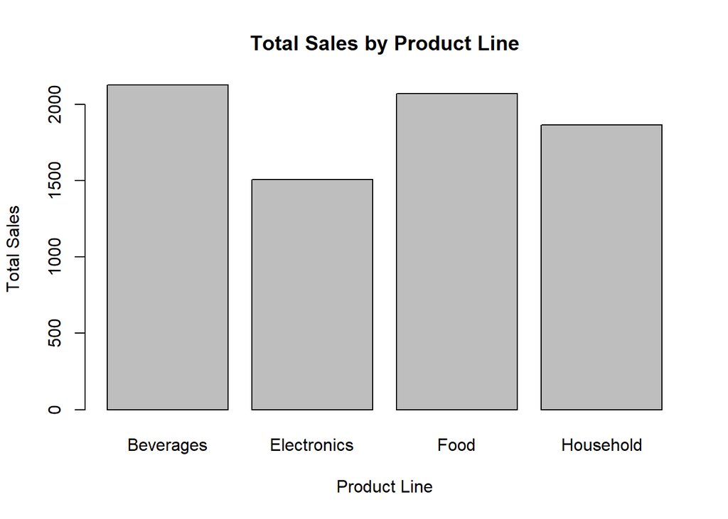

```r
sales_by_product <- aggregate(Total_Sales ~ Product_Line, data = data, sum)

barplot(
  sales_by_product$Total_Sales,
  names.arg = sales_by_product$Product_Line,
  main = "Total Sales by Product Line",
  xlab = "Product Line",
  ylab = "Total Sales"
)
```

## 2. Sales by Branch

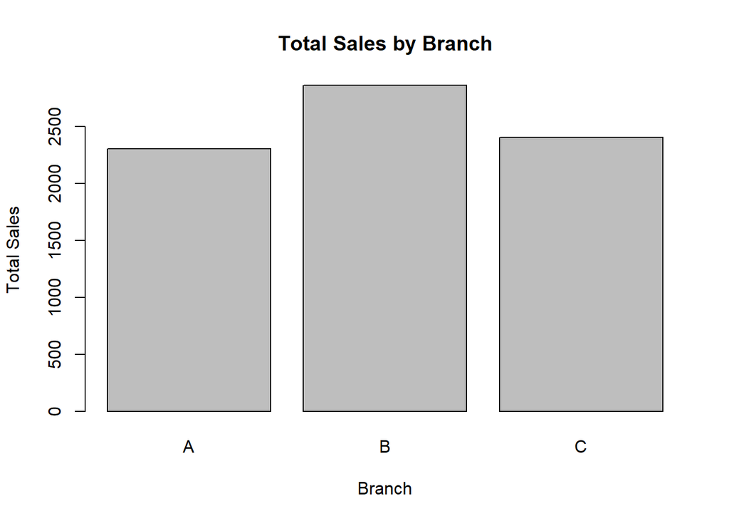

```r
sales_by_branch <- aggregate(Total_Sales ~ Branch, data = data, sum)

barplot(
  sales_by_branch$Total_Sales,
  names.arg = sales_by_branch$Branch,
  main = "Total Sales by Branch",
  xlab = "Branch",
  ylab = "Total Sales"
)
```

## 3. Sales Distribution

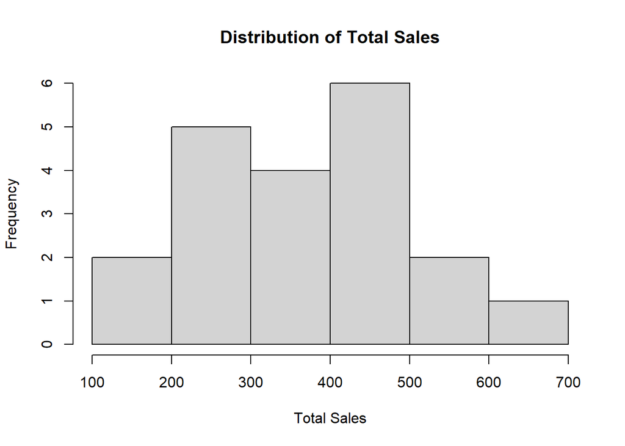

```r
hist(
  data$Total_Sales,
  main = "Distribution of Total Sales",
  xlab = "Total Sales",
  ylab = "Frequency"
)
```

## 4. Quantity vs Total Sales

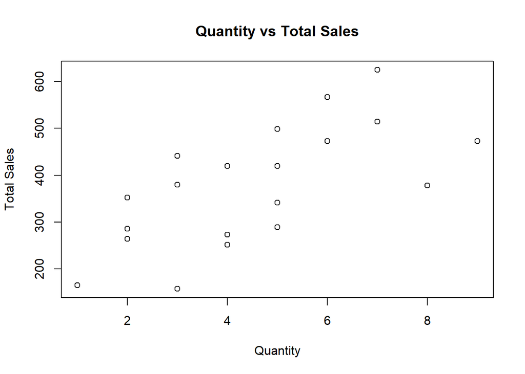

```r
plot(
  data$Quantity,
  data$Total_Sales,
  main = "Quantity vs Total Sales",
  xlab = "Quantity",
  ylab = "Total Sales"
)
```

## 5. Sales by Payment Method

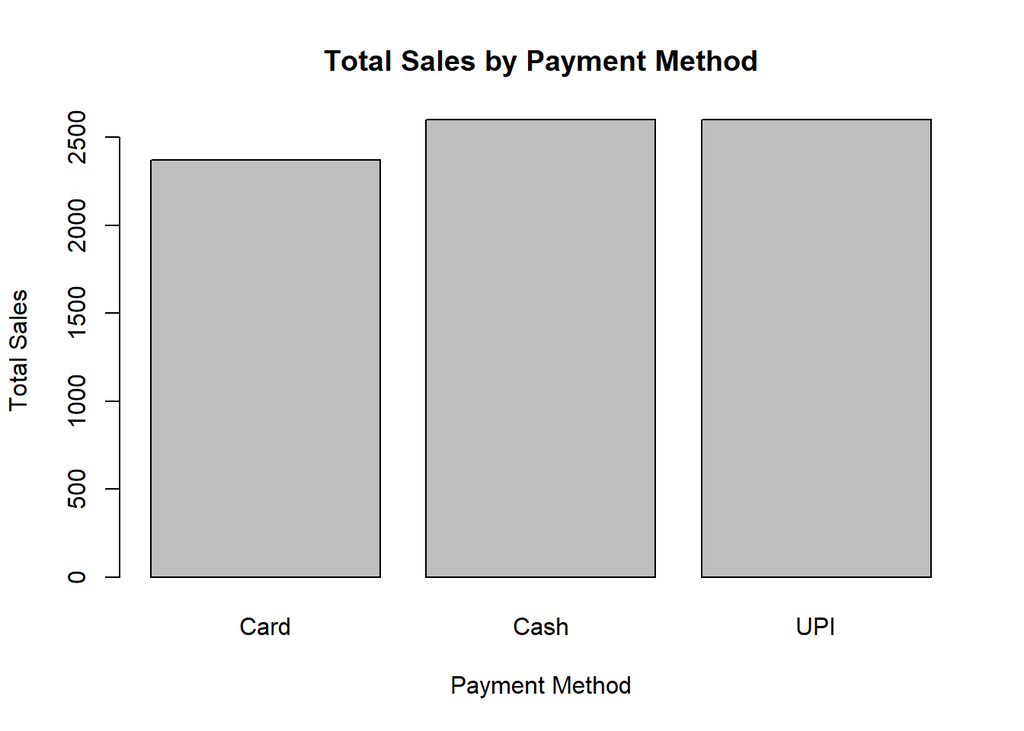

```r
sales_by_payment <- aggregate(Total_Sales ~ Payment, data = data, sum)

barplot(
  sales_by_payment$Total_Sales,
  names.arg = sales_by_payment$Payment,
  main = "Total Sales by Payment Method",
  xlab = "Payment Method",
  ylab = "Total Sales"
)
```

# Interpretation of Results

## Product Line Analysis

The bar chart shows the total sales for different product lines. It helps us compare which product categories generate more sales.

## Branch Analysis

The branch-wise sales chart shows the difference in sales between different supermarket branches.

## Sales Distribution

The histogram shows how the total sales values are distributed. It helps us understand the general pattern of sales.

## Quantity and Sales Analysis

The scatter plot shows the relationship between quantity sold and total sales. It helps us understand whether higher quantities are associated with higher sales.

## Payment Method Analysis

The analysis of supermarket sales data provides the following findings:

- Different product lines have different levels of sales.
- Sales vary among the different supermarket branches.
- The quantity of products sold has a relationship with total sales.
- Customers use different payment methods such as Cash, Card, and UPI.
- Statistical analysis helps us understand the overall sales performance.
- Graphs make it easier to compare sales and identify patterns in the data.

# Conclusion

This project analyzed supermarket sales data using R.

The data was imported, cleaned, and statistically analyzed. Different graphs were created to understand sales patterns, product performance, branches, quantity, and payment methods.

R is useful for analyzing data and presenting the results in a simple and understandable form.